# Centralized vs Individual Queues in Real World Settings

Author

GROUP 1

Published

March 5, 2026

# Abstract

Queue configuration has remained in the limelight in the performance of service systems, as it affects waiting times, fairness, and operational efficiency. Mathematically, the classical queueing theory suggests that pooling servers behind a single centralized queue reduces waiting-time variability and improves performance relative to multiple individual queues operating under uniform load. However, a lot of real-world scenarios, including supermarkets, banks, and airport checkpoints, continue to employ either individual or hybrid queue strategies. In this project, we use discrete-event simulation in R to compare centralized and individual queues under identical arrival and service conditions, evaluating performance in terms of average waiting time and variability. We will first confirm the theoretical advantage of a centralized queue and then discuss the operational considerations in different real-world settings.

# Introduction

Queueing systems are essential to the operation of modern service environments, including supermarkets, banks, and airport checkpoints. A fundamental design decision in such systems concerns the configuration of customer lines: whether customers from a single centralized queue feeding multiple servers, or multiple independent queues each assigned to an individual server. Although this choice appears operationally simple, it has significant implications for waiting time, fairness, and efficiency.

The distinction between centralized and individual queue structures is related to the concept of resource pooling in queuing theory and operational research. Resource pooling refers to the practice of combining multiple service resources so that they operate as single shared capacity rather than as fragmented, independent units. In a pooled system, all customers wait in a common queue and are served by the first available server. In contrast, in an unpooled or decentralized system, service capacity is partitioned into individual queues, leading to potential imbalance if some servers are idle while others have waiting customers. The performance advantage of centralized queues is often attributed to this pooling effect. However, despite the theoretical advantage proven by rigorous mathematics, individual queuing systems still exist.

This project investigates the performance implications of centralized versus individual queues using discrete-event simulation in R. We first conduct a baseline comparison by looking into the difference between the average waiting times and variabilities of a centralized and a parallel independent queue under identical arrival and service conditions. We aim to prove the mathematical conclusion that a centralized queue outperforms individual queues under the same situation, as suggested by the classical queueing theory.

Beyond this baseline comparison, we aim to test the sensitivity of this performance difference to various real-world constraints and system characteristics, such as space and staffing constraints, service-time heterogeneity, customer choice behavior, etc, and investigate whether and how the theoretical advantage of centralized queues hold under these situations.

# Centralized vs Individual Queues: A Mathematical Benchmark

## Baseline Assumptions

### Centralized Queue (M/M/c)

In a centralized queue, or a pooled system, customers arrive according to a Poisson process with rate $\lambda$ and join a single queue served by $c$ identical servers. Service times are exponentially distributed with rate $\mu$. This corresponds to the classical $M/M/c$ model.

### Individual Queues (Parallel M/M/1)

In a system of parallel individual queues, or an unpooled system, customers arrive according to the same Poisson process with rate $\lambda$, and each customer intuitively chooses the shortest one of the $c$ independent queues. Each queue operates as an $M/M/1$ system with service rate $\mu$.

### Performance Metrics

To ensure a fair comparison, both queuing systems operate under identical total service capacity $c\mu$ and identical arrival rate $\lambda$, with the traffic intensity
$$\rho = \frac{\lambda}{c\mu} < 1$$

## Theoretical Comparison

Theoretically, a centralized queuing system reduces the average waiting time with the advantage arising from the resource pooling principle. In a centralized queue setting, any idle server immediately serves the next waiting customer. In contrast, under parallel independent queues, one server may be idle while customers are waiting in another queue. This imbalance increases the variability of waiting time.

Classical queuing theory shows that, for identical total service capacity and arrival rate, the expected waiting time in an M/M/c system is generally lower than in $c$ independent M/M/1 queues with random routing. This difference becomes more significant as service-time variability increases.

Therefore, under idealized assumptions of identical servers, exponential service times, and no behavioral constraints, a centralized queue is expected to outperform individual queues.

## Baseline R Simulations

To verify the theoretical mathematical result, we conduct a discrete-event simulation in R comparing the two systems under identical arrival and service assumptions.

Customers arrive according to a Poisson process with rate $\lambda$, and service times follow an exponential distribution with rate $\mu$. The number of servers $c$ and traffic intensity $\rho$ are held constant across both systems. Each simulation run processes $N$ customers, and performance metrics are computed after a warm-up period to reduce bias induced by the burn-in effect.

We will also use the code in this section as the baseline for both queuing systems and investigate the effects of the real-world constraints.

The centralized and individual queuing systems are coded as follows:

```r
# Centralized queues
centralized_queue <- function(arrivals, service, c) {
  n <- length(arrivals)
  wait <- numeric(n)
  free_time <- rep(0, c)

  for (i in 1:n) {
    j <- which.min(free_time)
    start <- max(arrivals[i], free_time[j])
    wait[i] <- start - arrivals[i]
    free_time[j] <- start + service[i]
  }
  wait
}
```

```r
# Individual queues
individual_queue <- function(arrivals, service, c) {
  n <- length(arrivals)
  wait <- numeric(n)
  q_dep <- replicate(c, numeric(0), simplify = FALSE)

  for (i in 1:n) {
    t <- arrivals[i]

    # Remove customers already departed by time t
    for (j in 1:c) {
      if (length(q_dep[[j]]) > 0) {
        q_dep[[j]] <- q_dep[[j]][q_dep[[j]] > t]
      }
    }

    # Join shortest queue (tie broken randomly)
    lens <- vapply(q_dep, length, integer(1))
    candidates <- which(lens == min(lens))
    j <- sample(candidates, 1)

    # FCFS start time in chosen queue
    last_dep <- if (length(q_dep[[j]]) == 0) t else tail(q_dep[[j]], 1)
    start <- max(t, last_dep)

    wait[i] <- start - t
    q_dep[[j]] <- c(q_dep[[j]], start + service[i])
  }
  wait
}
```

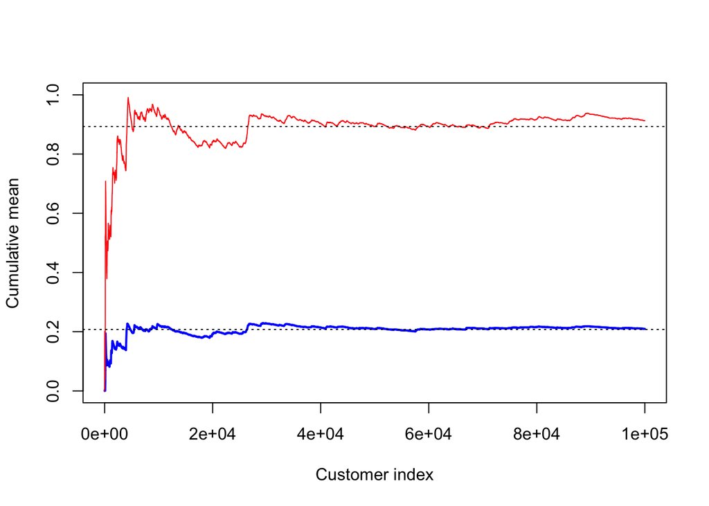

Burn-in process diagnostic plot

```r
check_burn_in <- function(
  lambda = 8,
  mu = 1,
  c = 10,
  n = 100000,
  seed = 42
) {
  set.seed(seed)
  arrivals <- cumsum(rexp(n, rate = lambda))
  service <- rexp(n, rate = mu)

  w_c <- centralized_queue(arrivals, service, c)
  w_i <- individual_queue(arrivals, service, c)

  cum_mean_c <- cumsum(w_c) / seq_along(w_c)
  cum_mean_i <- cumsum(w_i) / seq_along(w_i)

  plot(
    cum_mean_c,
    type = "l",
    lwd = 2,
    col = "blue",
    ylim = c(0, 1),
    xlab = "Customer index",
    ylab = "Cumulative mean"
  )
  lines(cum_mean_i, col = "red")
  abline(h = mean(cum_mean_c), lty = 3)
  abline(h = mean(cum_mean_i), lty = 3)
}

check_burn_in()
```

```r
simulate_queue <- function(
  lambda = 8,
  mu = 1,
  c = 10,
  n = 100000,
  warmup = 35000,
  seed = 1
) {
  set.seed(seed)
  arrivals <- cumsum(rexp(n, rate = lambda))
  service <- rexp(n, rate = mu)

  w_c <- centralized_queue(arrivals, service, c)
  w_i <- individual_queue(arrivals, service, c)

  idx <- (warmup + 1):n
  c(
    central_mean = mean(w_c[idx]),
    individual_mean = mean(w_i[idx])
  )
}

run_simulations <- function(
  R = 10,
  sim_func = simulate_queue,
  seed_start = 1000,
  ...
) {
  out <- t(sapply(seq_len(R), function(r) {
    sim_func(seed = seed_start + r, ...)
  }))
  as.data.frame(out)
}
```

```r
baseline_sim <- run_simulations()
baseline_mean_diff <- baseline_sim$individual_mean - baseline_sim$central_mean
```

Average Waiting Time of Both Queuing Systems

|  | Centralized Queue | Individual Queues |
| --- | --- | --- |
| Avg Waiting Time | 0.1984 | 0.8722 |

We can also compare the results by conducting a one sample t-test. The test result provides a p-value of $p < 1e-4$, which is significantly small. At a confidence level of 95%, we reject the null hypthesis that the true mean of difference between average centralized waiting time and average individual waiting time is 0.

# Real-World Constraints and Scenario Modelling

## Real-World Constraints

The baseline model relies heavily on strong assumptions that may not hold in practice. Real-world systems may often include:

- Heterogeneous service rates (e.g., experienced vs junior staff)
- Physical space constraints (may limit the size of the queue)
- Behavioral queue choice (e.g., customers may choose visually shorter queues)
- Non-uniform parameters within/across queuing systems.

and etc. These constraints may weaken or even overthrow the theoretical advantage of centralized queues in practice.

## Constraint Analysis

To investigate how the real-world constraints act on the performances of queuing systems, we construct stylized scenarios reflecting real service environments.

### Heterogeneous Service Rate

The baseline model assumes homogeneous service rates, meaning that all customers require service times drawn from the same exponential distribution with rate $\mu$. In real service systems, however, this assumption rarely holds. Transaction times may vary substantially due to differences in customer needs or worker productivity. These differences introduce heterogeneous service ratesi, which can arise from two main sources: server-side variability and customer-side variability.

#### Server-Side Heterogeneity

Server-side heterogeneity occurs when workers differ in productivity or experience. In many real service systems, employees do not process customers at identical speeds. For example, experienced staff may complete transactions faster than junior employees, or some airport officers may handle inspections more efficiently than others.

A simple way to represent this is to divide servers into two groups with different service rates. A fraction of servers operate at a faster service rate $\mu_{\text{fast}}$, while the remaining servers operate at a slower rate $\mu_{\text{slow}}$. This captures differences in worker efficiency across the service system.

#### Customer-Side Heterogeneity

Customer-side heterogeneity arises when different customers require different amounts of service work. In many service environments, the workload associated with each customer can vary substantially. For example, in supermarkets customers arrive with baskets containing different numbers of items, while in airport customs some passengers may require additional document checks or clarification, leading to longer processing times. These differences naturally generate variation in service durations even when workers follow similar procedures.

To capture this variability, we model service time as a function of basket size. For each arriving customer, the number of items is drawn from a Poisson distribution with mean $\lambda_\text{items}$. The service time is then constructed as

$$S = \text{Baseline Waiting Time} + \text{Per Item Time} \times B + \epsilon$$

where $B$ denotes the basket size and $\epsilon \sim \text{Exp}(10)$ denotes the random noise capturing minor operational delays such as scanning errors or payment processing. The parameter $\text{Baseline Waiting Time}$ represents the fixed service overhead, while $\text{Per Item Time}$ represents the time required to process each time.

This formulation introduces heterogeneous service times across customers while keeping the queueing structure identical to the baseline model. It therefore allows the simulation to capture realistic variation in service durations while isolating the effect of customer-driven workload differences.

```r
generate_service_basket <- function(
  n,
  mean_items = 12,
  base_time = 0.15,
  per_item_time = 0.04,
  noise_rate = 10,
  seed = 1
) {
  set.seed(seed)
  B <- rpois(n, lambda = mean_items)
  base_time + per_item_time * B + rexp(n, rate = noise_rate)
}
```

We run the simulations under the heterogeneous service time specification using the same system parameters as in the baseline model. Each run generates $n=100000$ arrivals, with the first $35000$ observations discarded to avoid burn-in effect before computing summary statistics.

```r
generate_service_basket <- function(
  n,
  mean_items = 12,
  base_time = 0.3,
  per_item_time = 0.06,
  noise_rate = 10,
  seed = 5
) {
  B <- rpois(n, lambda = mean_items)
  base_time + per_item_time * B + rexp(n, rate = noise_rate)
}
simulate_queue_hetero <- function(
  lambda = 8,
  c = 10,
  n = 100000,
  warmup = 35000,
  mean_items = 12,
  base_time = 0.3,
  per_item_time = 0.06,
  noise_rate = 10,
  seed = 1
) {
  arrivals <- cumsum(rexp(n, rate = lambda))

  service <- generate_service_basket(
    n = n,
    mean_items = mean_items,
    base_time = base_time,
    per_item_time = per_item_time,
    noise_rate = noise_rate,
  )

  w_c <- centralized_queue(arrivals, service, c)
  w_i <- individual_queue(arrivals, service, c)

  idx <- (warmup + 1):n
  c(
    central_mean = mean(w_c[idx]),
    individual_mean = mean(w_i[idx])
  )
}

R <- 10
out_hetero <- t(sapply(seq_len(R), function(r) {
  simulate_queue_hetero(seed = 2000 + r)
}))
out_hetero <- as.data.frame(out_hetero)

d_mean_hetero <- out_hetero$individual_mean - out_hetero$central_mean
```

Average Waiting Time under Heterogeneous Service (Basket Size)

|  | Centralized Queue | Individual Queues |
| --- | --- | --- |
| Avg Waiting Time | 0.3809 | 1.1306 |
| Reduction (%) | - | 66.31 |

We can also compare the results by conducting a one-sample t-test. The test result provides a p-value of $p < 1e-4$, which is extremely small. At a confidence level of 95%, we reject the null hypothesis that the true mean difference between the average waiting time of the centralized queue and that of the individual queues is zero. This indicates that the centralized queue consistently achieves lower waiting times under heterogeneous service conditions.

Heterogeneous service rates increase the variability of service times and therefore amplify the risk of temporary imbalances across queues. In decentralized systems with individual queues, a long transaction or a slower worker can create persistent congestion in a single lane, while other servers may remain underutilized. In contrast, centralized queues pool demand across servers, allowing the system to absorb such variability more efficiently. Consequently, heterogeneous service rates are expected to increase both the average waiting time and the dispersion of waiting times in decentralized queue structures, strengthening the relative advantage of centralized queueing systems.

### Walking Time Constraint

Another practical constraint that may weaken the theoretical advantage of centralized queues arises from physical movement within the service area. In the classical M/M/c model, customers from a centralized queue are assumed to immediately begin service when a server becomes available. In reality, however, customers must often walk to the available service point after being called forward. This is common in environments such as supermarkets, airport immigration checkpoints, or bank counters where servers are spatially separated.

To incorporate this practical constraint, we introduce a walking time between the moment a server becomes free and the moment the customer actually begins service. In the simulation, this walking time is generated from a uniform distribution between 0 and a specified maximum value. The uniform distribution provides a simple approximation of real service environments, where customers may be positioned at different distances from the service desk, such as in airport immigration lines or supermarket checkouts. This delay therefore represents the time required for the customer to walk from the queue to the assigned service desk.

```r
set.seed(15)
simulate_centralized_walk <- function(
  N = 10000,
  lambda = 8,
  mu = 1,
  c = 10,
  walk_max = 0.25
) {
  inter_arrivals <- rexp(N, rate = lambda)
  arrivals <- cumsum(inter_arrivals)

  free_time <- rep(0, c)

  waits <- numeric(N)
  totals <- numeric(N)

  for (i in 1:N) {
    j <- which.min(free_time)
    start_no_walk <- max(arrivals[i], free_time[j])
    walk <- runif(1, min = 0, max = walk_max)

    start <- start_no_walk + walk

    service <- rexp(1, rate = mu)

    free_time[j] <- start + service
    waits[i] <- start_no_walk - arrivals[i]
    totals[i] <- (start - arrivals[i]) + service
  }
  round(mean(waits), 4)
}

central_mean_walk <- simulate_centralized_walk()
```

Average Waiting Time of Both Queuing Systems

|  | Centralized Queue (with walk) | Individual Queues |
| --- | --- | --- |
| Avg Waiting Time | 0.9099 | 0.8722 |

The key effect of introducing walking time is the creation of server idle periods. In the classical $M/M/c$ model, servers immediately begin serving the next waiting customer, ensuring full utilization of service capacity. When walking time is added, however, the server remains idle during the customer’s travel time, even though the next customer has already been selected. As a result, the system temporarily loses service capacity.

This mechanism effectively reduces the operational efficiency of the pooled servers. While the arrival and service distributions remain unchanged, the additional delay increases the time between consecutive services. Since centralized queues rely on the efficient use of pooled service capacity, these idle periods weaken the theoretical advantage predicted by the baseline model.

Our simulation results illustrate this effect clearly. When walking time is introduced, compared to the baseline individual queuing system (since the walking time for the individual queuing system is negligible), the centralized queue is less efficient in terms of average waiting time. In our simulation, the average waiting time for the centralized queue is approximately 0.9099, while the independent queue produces a lower average waiting time of 0.8722. This result is particularly important because it shows that once realistic operational constraints are introduced, the classical theoretical result that centralized queues always outperform individual queues may no longer hold. In this scenario, the additional idle time created by customer movement reduces the benefits of pooling servers, allowing the independent queue system to perform slightly better.

The results therefore illustrate how idle time induced by realistic environmental constraints can introduce inefficiencies that are not captured by the classical queueing theory, explaining why centralized queues may perform less efficiently in practice than theory would suggest.

### Spacing Constraint

To study the spacing limitations, we first translate the practical issue in reality into a mathematical constraint. The key mechanism is that limited physical space induces a finite queue capacity. Therefore, we choose to impose a capacity cap in both queuing systems. A total system capacity $K_c$ for the centralized queue, and a per-queue capacity $K_i$ for individual queues. To ensure the two queuing systems are being compared under matched situations, we need to impose that
$$K_c = c \times K_i$$
where $c$ is the number of servers in each queuing system. When the relevant capacity is full, new arrivals are blocked. This allows us to quantify how space constraints affect waiting times and service access under each queuing system.

```r
centralized_queue_cap <- function(arrivals, service, c, Kc = Inf) {
  n <- length(arrivals)
  wait <- rep(NA_real_, n)
  n_reject <- 0L
  free_time <- rep(0, c)
  dep_all <- numeric(0)

  for (i in 1:n) {
    t <- arrivals[i]
    if (length(dep_all) > 0) {
      dep_all <- dep_all[dep_all > t]
    }

    if (length(dep_all) >= Kc) {
      n_reject <- n_reject + 1L
      next
    }

    j <- which.min(free_time)
    start <- max(t, free_time[j])
    wait[i] <- start - t
    dep <- start + service[i]
    free_time[j] <- dep
    dep_all <- c(dep_all, dep)
  }

  wait
}

individual_queue_cap <- function(arrivals, service, c, Ki = Inf) {
  n <- length(arrivals)
  wait <- rep(NA_real_, n)
  n_reject <- 0L
  q_dep <- replicate(c, numeric(0), simplify = FALSE)

  for (i in 1:n) {
    t <- arrivals[i]

    for (j in 1:c) {
      if (length(q_dep[[j]]) > 0) {
        q_dep[[j]] <- q_dep[[j]][q_dep[[j]] > t]
      }
    }

    lens <- vapply(q_dep, length, integer(1))
    if (all(lens >= Ki)) {
      n_reject <- n_reject + 1L
      next
    }

    min_len <- min(lens[lens < Ki])
    candidates <- which(lens == min_len & lens < Ki)
    j <- candidates[sample.int(length(candidates), 1)]

    last_dep <- if (length(q_dep[[j]]) == 0) t else tail(q_dep[[j]], 1)
    start <- max(t, last_dep)
    wait[i] <- start - t
    q_dep[[j]] <- c(q_dep[[j]], start + service[i])
  }
  wait
}
```

```r
simulate_queue_cap <- function(
  lambda = 8,
  mu = 1,
  c = 10,
  n = 100000,
  warmup = 35000,
  Kc = Inf, # centralized total capacity
  Ki = Inf, # individual per-queue capacity
  seed = 1
) {
  set.seed(seed)
  arrivals <- cumsum(rexp(n, rate = lambda))
  service <- rexp(n, rate = mu)

  res_c <- centralized_queue_cap(arrivals, service, c, Kc = Kc)
  res_i <- individual_queue_cap(arrivals, service, c, Ki = Ki)

  idx <- (warmup + 1):n

  c(
    central_mean = mean(res_c, na.rm = TRUE),
    individual_mean = mean(res_i, na.rm = TRUE)
  )
}

run_simulations_cap <- function(
  sim_func = simulate_queue_cap,
  R = 10,
  lambda = 8,
  mu = 1,
  c = 10,
  Ki = 5,
  Kc = c * Ki,
  seed = 1000
) {
  out <- t(sapply(seq_len(R), function(r) {
    sim_func(
      lambda = lambda,
      mu = mu,
      c = c,
      seed = seed + r,
      Kc = Kc,
      Ki = Ki
    )
  }))
  as.data.frame(out)
}

space_lim_result <- run_simulations_cap()
space_mean_diff <- space_lim_result$individual_mean -
  space_lim_result$central_mean
```